# TO 628 Final Team Project

Team 7: Xuhao Dai, Anubhav Gupta, Yongsoo Shin, Priti Singh, Brian Tsai

Due on April 20, 2020

# 1 Class Topics

So far, we have learned about the following topics. For this project, one or more of the following options will be pursued for modeling and detailed analysis.

1. Linear Regression
2. Logistic Regression
3. KNN
4. ANN
5. SVM
6. Decision Trees
7. Random Forest

# 2 Motivation

# 3 Read Me

This document presents the group project for which city bike data in NYC is used. The purpose of this document is to share analysis of the influence of weather to the bike usage.

Here, city bike data from 2019 will be used for the analysis. Specifically, 5% of the entire 2019 data was extracted, and the extracted data was categorized into average ride usage per day (365 days in total). Thereafter, the yearly usage data was randomly divided into train (80%, 292 days) and test (20%, 73 days) for the modeling, testing the accuracy of the models, and business analytics.

Ultimately, the findings will be used to identify the relationship between weather and bike usage and predict the bike usage based on chosen parameters (e.g. precipitation amount). Thereafter, some insights will be presented for the bike business.

Note that there was an effort to retrieve station capacity information into the dataset. However, it was not pursued as only 20% of the stations in the dataset were identified with the capacity.

# 4 Dataset Explanation

- City bike data in NYC
- Each dataset is comprised of 1 month trip data
  - Data from 12 months of 2019 have been combined and divided into train (80%) and test (20%) datasets.
- Variables (City bike):
  - trip duration (sec)
  - start time (year, month, day, time)
  - stop time (year, month, day, time)
  - start station (id, lat/long)
  - end station (id, lat/long)
  - bike id
  - user type
    - customer (24 hr vs 3 day)
    - subscriber (annual)
  - birth year
  - gender (0, 1, 2 = unknown, male, female)
  - trip distance (based on the lat/long, trip distance was calculated with r package haversine)
  - trip speed (based on trip distance, trip speed was calculated with trip duration)
  - total # bike rentals (per day)
- Variables (Weather):
  - TMIN (minimum temperature in C)
  - TMAX (maximum temperature in C)
  - Average wind speed
  - PRCP (mm)
  - SNOW (mm)

# 5 Load Datasets

```r
#load train dataset
traindata = read.csv("train_final.csv")

#load test dataset
testdata = read.csv("test_final.csv")

#load data - station information
#station_info = read.csv("station_information.csv")
```

# 6 Clean up Datasets

Ensure that no additional clean up is needed after train and test datasets are extracted from the entire 2019 usage.

```r
#train dataset
traindata$X = NULL
traindata$Date = NULL
traindata$start_station_id = as.integer(traindata$start_station_id)
colnames(traindata)
```

```
##  [1] "start_month"       "start_day"         "start_station_id"
##  [4] "usertype"          "day"               "age_group"
##  [7] "time"              "day_count"         "avg_wind_speed"
## [10] "TMIN"              "TMAX"              "PRCP"
## [13] "SNOW"              "avg_trip_duration" "avg_speed"
## [16] "frequency"
```

```r
str(traindata)
```

```
## 'data.frame':    551829 obs. of  16 variables:
##  $ start_month      : int  1 1 1 1 1 1 1 1 1 1 ...
##  $ start_day        : int  1 1 1 1 1 1 1 1 1 1 ...
##  $ start_station_id : int  749 792 89 397 199 200 778 784 206 88 ...
##  $ usertype         : Factor w/ 2 levels "Customer","Subscriber": 2 2 2 2 2 2 2 2 2 2 ...
##  $ day              : Factor w/ 7 levels "Friday","Monday",..: 6 6 6 6 6 6 6 6 6 6 ...
##  $ age_group        : Factor w/ 4 levels "Adult","Elderly",..: 2 1 3 1 3 3 1 1 1 3 ...
##  $ time             : Factor w/ 4 levels "afternoon","evening",..: 1 3 2 2 1 3 1 1 2 2 ...
##  $ day_count        : int  1 1 1 1 1 1 1 1 1 1 ...
##  $ avg_wind_speed   : num  0 0 0 0 0 0 0 0 0 0 ...
##  $ TMIN             : num  3.9 3.9 3.9 3.9 3.9 3.9 3.9 3.9 3.9 3.9 ...
##  $ TMAX             : num  14.4 14.4 14.4 14.4 14.4 14.4 14.4 14.4 14.4 14.4 ...
##  $ PRCP             : num  1.5 1.5 1.5 1.5 1.5 1.5 1.5 1.5 1.5 1.5 ...
##  $ SNOW             : num  0 0 0 0 0 0 0 0 0 0 ...
##  $ avg_trip_duration: num  1378 820 1287 950 192 ...
##  $ avg_speed        : num  2.6 1.91 2.63 1.84 2.47 ...
##  $ frequency        : int  1 1 1 2 1 3 3 2 2 1 ...
```

```r
summary(traindata)
```

```
##   start_month       start_day    start_station_id       usertype
##  Min.   : 1.000   Min.   : 1.0   Min.   :  1.0    Customer  : 94173
##  1st Qu.: 4.000   1st Qu.: 8.0   1st Qu.:186.0    Subscriber:457656
##  Median : 7.000   Median :15.0   Median :411.0
##  Mean   : 6.646   Mean   :15.2   Mean   :428.2
##  3rd Qu.: 9.000   3rd Qu.:22.0   3rd Qu.:710.0
##  Max.   :12.000   Max.   :31.0   Max.   :828.0
##
##         day             age_group             time          day_count
##  Friday   :86283   Adult     :334701   afternoon:139095   Min.   :  1.0
##  Monday   :77317   Elderly   : 17920   evening  :164354   1st Qu.:109.0
##  Saturday :86853   Middle Age:190794   morning  :163446   Median :190.0
##  Sunday   :71198   Teenager  :  8414   night    : 84934   Mean   :186.1
##  Thursday :77026                                          3rd Qu.:258.0
##  Tuesday  :83447                                          Max.   :364.0
##  Wednesday:69705
##  avg_wind_speed       TMIN             TMAX            PRCP
##  Min.   :0.000   Min.   :-16.60   Min.   :-9.90   Min.   : 0.000
##  1st Qu.:1.200   1st Qu.:  3.90   1st Qu.:11.70   1st Qu.: 0.000
##  Median :1.600   Median : 12.80   Median :21.70   Median : 0.000
##  Mean   :1.712   Mean   : 11.35   Mean   :19.35   Mean   : 2.744
##  3rd Qu.:2.300   3rd Qu.: 18.90   3rd Qu.:27.20   3rd Qu.: 1.500
##  Max.   :5.700   Max.   : 26.70   Max.   :35.00   Max.   :46.500
##
##       SNOW          avg_trip_duration   avg_speed       frequency
##  Min.   : 0.00000   Min.   :   61.0   Min.   :0.000   Min.   : 1.000
##  1st Qu.: 0.00000   1st Qu.:  392.0   1st Qu.:1.935   1st Qu.: 1.000
##  Median : 0.00000   Median :  647.3   Median :2.481   Median : 1.000
##  Mean   : 0.07141   Mean   :  848.1   Mean   :2.408   Mean   : 1.451
##  3rd Qu.: 0.00000   3rd Qu.: 1080.0   3rd Qu.:2.967   3rd Qu.: 2.000
##  Max.   :10.20000   Max.   :17859.0   Max.   :8.432   Max.   :23.000
##
```

```r
#test dataset
testdata$X = NULL
testdata$Date = NULL
testdata$start_station_id = as.integer(testdata$start_station_id)
colnames(testdata)
```

```
##  [1] "start_month"       "start_day"         "start_station_id"
##  [4] "usertype"          "day"               "age_group"
##  [7] "time"              "day_count"         "avg_wind_speed"
## [10] "TMIN"              "TMAX"              "PRCP"
## [13] "SNOW"              "avg_trip_duration" "avg_speed"
## [16] "frequency"
```

```r
str(testdata)
```

```
## 'data.frame':    148349 obs. of  16 variables:
##  $ start_month      : int  1 1 1 1 1 1 1 1 1 1 ...
##  $ start_day        : int  6 6 6 6 6 6 6 6 6 6 ...
##  $ start_station_id : int  813 530 638 821 318 65 86 345 128 788 ...
##  $ usertype         : Factor w/ 2 levels "Customer","Subscriber": 2 2 1 2 2 2 2 2 2 2 ...
##  $ day              : Factor w/ 7 levels "Friday","Monday",..: 4 4 4 4 4 4 4 4 4 4 ...
##  $ age_group        : Factor w/ 4 levels "Adult","Elderly",..: 1 1 3 1 1 1 1 1 1 1 ...
##  $ time             : Factor w/ 4 levels "afternoon","evening",..: 1 2 1 3 3 1 1 2 3 2 ...
##  $ day_count        : int  6 6 6 6 6 6 6 6 6 6 ...
##  $ avg_wind_speed   : num  0 0 0 0 0 0 0 0 0 0 ...
##  $ TMIN             : num  -0.5 -0.5 -0.5 -0.5 -0.5 -0.5 -0.5 -0.5 -0.5 -0.5 ...
##  $ TMAX             : num  9.4 9.4 9.4 9.4 9.4 9.4 9.4 9.4 9.4 9.4 ...
##  $ PRCP             : num  0 0 0 0 0 0 0 0 0 0 ...
##  $ SNOW             : int  0 0 0 0 0 0 0 0 0 0 ...
##  $ avg_trip_duration: num  516 685 720 532 2042 ...
##  $ avg_speed        : num  2 2.69 1.66 3.36 1.81 ...
##  $ frequency        : int  2 3 1 1 2 2 2 2 1 2 ...
```

```r
summary(testdata)
```

```
##   start_month       start_day     start_station_id       usertype
##  Min.   : 1.000   Min.   : 2.00   Min.   :  1.0    Customer  : 27591
##  1st Qu.: 5.000   1st Qu.: 9.00   1st Qu.:184.0    Subscriber:120758
##  Median : 7.000   Median :18.00   Median :409.0
##  Mean   : 7.275   Mean   :17.42   Mean   :426.9
##  3rd Qu.:10.000   3rd Qu.:26.00   3rd Qu.:708.0
##  Max.   :12.000   Max.   :31.00   Max.   :827.0
##
##         day             age_group            time         day_count
##  Friday   :18062   Adult     :90298   afternoon:37667   Min.   :  6.0
##  Monday   :19895   Elderly   : 4668   evening  :44357   1st Qu.:147.0
##  Saturday :17199   Middle Age:50931   morning  :43497   Median :205.0
##  Sunday   :19230   Teenager  : 2452   night    :22828   Mean   :207.4
##  Thursday :22388                                        3rd Qu.:280.0
##  Tuesday  :19484                                        Max.   :365.0
##  Wednesday:32091
##  avg_wind_speed      TMIN             TMAX            PRCP
##  Min.   :0.00   Min.   :-14.30   Min.   : 0.00   Min.   : 0.000
##  1st Qu.:1.30   1st Qu.:  7.80   1st Qu.:16.10   1st Qu.: 0.000
##  Median :1.60   Median : 13.90   Median :21.10   Median : 0.000
##  Mean   :1.82   Mean   : 12.96   Mean   :21.09   Mean   : 2.914
##  3rd Qu.:2.20   3rd Qu.: 19.40   3rd Qu.:28.30   3rd Qu.: 1.000
##  Max.   :5.20   Max.   : 27.80   Max.   :35.00   Max.   :46.200
##
##       SNOW          avg_trip_duration   avg_speed       frequency
##  Min.   :0.000000   Min.   :   61.0   Min.   :0.000   Min.   : 1.000
##  1st Qu.:0.000000   1st Qu.:  401.0   1st Qu.:1.911   1st Qu.: 1.000
##  Median :0.000000   Median :  664.5   Median :2.466   Median : 1.000
##  Mean   :0.006377   Mean   :  864.2   Mean   :2.386   Mean   : 1.479
##  3rd Qu.:0.000000   3rd Qu.: 1104.0   3rd Qu.:2.950   3rd Qu.: 2.000
##  Max.   :1.000000   Max.   :17862.0   Max.   :7.206   Max.   :21.000
##
```

# 7 Further Data Exploration

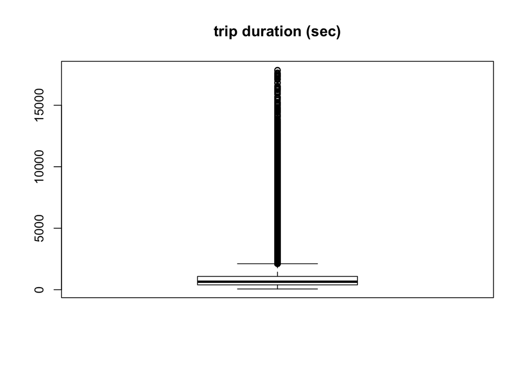

```r
#1. trip duration
boxplot(traindata$avg_trip_duration, main = "trip duration (sec)")
```

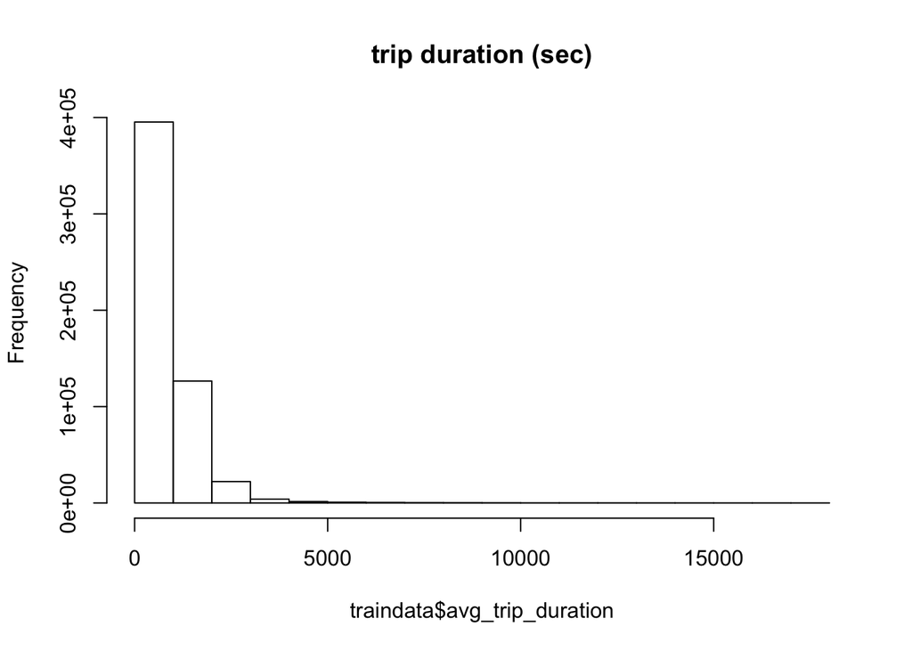

```r
hist(traindata$avg_trip_duration, main = "trip duration (sec)")
```

```r
#5. birth year
summary(traindata$age_group)
```

```
##      Adult    Elderly Middle Age   Teenager
##     334701      17920     190794       8414
```

```r
#6. user type
summary(traindata$usertype)
```

```
##   Customer Subscriber
##      94173     457656
```

# 8 Data Preparation for Modeling

Data has been reorganized to split the data per each day. Information about start day and end day are treated separately. The information of interest are: average birth year, average trip duration, and total check-ins/check-outs per given day.

```r
# Look for and download plyr package if it does not already exist
if (!require("plyr")) {
  install.packages("plyr")
}
#read in plyr package
library(plyr)

#organize data per day (avg trip duration, avg speed per day, total check out per day, avg travel distance per day)
train_per_day = ddply(traindata,.(start_month,start_day, avg_wind_speed, TMIN, TMAX, PRCP, SNOW), c(function(x) mean(x$avg_trip_duration), function(x) mean(x$avg_speed), function(x) sum(x$frequency)))
colnames(train_per_day) = c("start_month","start_day","avg_wind_speed","TMIN","TMAX","PRCP","SNOW","avg_trip_duration","avg_speed","frequency")

test_per_day = ddply(testdata,.(start_month,start_day, avg_wind_speed, TMIN, TMAX, PRCP, SNOW), c(function(x) mean(x$avg_trip_duration), function(x) mean(x$avg_speed), function(x) sum(x$frequency)))
colnames(test_per_day) = c("start_month","start_day","avg_wind_speed","TMIN","TMAX","PRCP","SNOW","avg_trip_duration","avg_speed","frequency")

head(train_per_day)
```

```
##   start_month start_day avg_wind_speed TMIN TMAX PRCP SNOW avg_trip_duration
## 1           1         1              0  3.9 14.4  1.5    0          917.5800
## 2           1         2              0  1.7  4.4  0.0    0          729.0894
## 3           1         3              0  2.8  6.7  0.0    0          724.9942
## 4           1         4              0  1.7  8.3  0.0    0          739.6375
## 5           1         5              0  5.0  8.3 12.7    0          659.4482
## 6           1         7              0 -3.8  1.1  0.0    0          670.9264
##   avg_speed frequency
## 1  2.238813      1136
## 2  2.521008      1866
## 3  2.571871      2065
## 4  2.543094      2163
## 5  2.518628       846
## 6  2.626848      1860
```

```r
summary(train_per_day)
```

```
##   start_month       start_day     avg_wind_speed       TMIN
##  Min.   : 1.000   Min.   : 1.00   Min.   :0.000   Min.   :-16.600
##  1st Qu.: 3.000   1st Qu.: 8.00   1st Qu.:0.900   1st Qu.:  1.100
##  Median : 6.000   Median :15.00   Median :1.600   Median :  9.400
##  Mean   : 6.387   Mean   :15.23   Mean   :1.676   Mean   :  8.874
##  3rd Qu.: 9.000   3rd Qu.:22.00   3rd Qu.:2.400   3rd Qu.: 17.200
##  Max.   :12.000   Max.   :31.00   Max.   :5.700   Max.   : 26.700
##       TMAX            PRCP             SNOW         avg_trip_duration
##  Min.   :-9.90   Min.   : 0.000   Min.   : 0.0000   Min.   : 542.2
##  1st Qu.: 7.80   1st Qu.: 0.000   1st Qu.: 0.0000   1st Qu.: 706.2
##  Median :17.20   Median : 0.000   Median : 0.0000   Median : 799.0
##  Mean   :16.52   Mean   : 3.647   Mean   : 0.1414   Mean   : 814.8
##  3rd Qu.:25.60   3rd Qu.: 2.500   3rd Qu.: 0.0000   3rd Qu.: 888.3
##  Max.   :35.00   Max.   :46.500   Max.   :10.2000   Max.   :1168.4
##    avg_speed       frequency
##  Min.   :2.040   Min.   : 522
##  1st Qu.:2.363   1st Qu.:1842
##  Median :2.452   Median :2819
##  Mean   :2.437   Mean   :2742
##  3rd Qu.:2.545   3rd Qu.:3684
##  Max.   :2.866   Max.   :4689
```

```r
head(test_per_day)
```

```
##   start_month start_day avg_wind_speed  TMIN TMAX PRCP SNOW avg_trip_duration
## 1           1         6              0  -0.5  9.4  0.0    0          733.9794
## 2           1        28              0  -3.8  3.3  0.0    0          650.7955
## 3           1        29              0  -3.8  6.1  5.8    0          658.9985
## 4           1        30              0 -14.3  1.7  0.3    1          636.5608
## 5           2         4              0   5.0 16.1  0.0    0          754.8000
## 6           2        18              0  -3.2  5.6  2.3    0          702.6888
##   avg_speed frequency
## 1  2.459605      1607
## 2  2.650070      1684
## 3  2.647706      1594
## 4  2.508030      1212
## 5  2.544449      2271
## 6  2.535576      1272
```

```r
summary(test_per_day)
```

```
##   start_month       start_day     avg_wind_speed       TMIN
##  Min.   : 1.000   Min.   : 2.00   Min.   :0.000   Min.   :-14.30
##  1st Qu.: 5.000   1st Qu.: 9.00   1st Qu.:1.200   1st Qu.:  5.60
##  Median : 7.000   Median :18.00   Median :1.600   Median : 12.80
##  Mean   : 7.082   Mean   :17.68   Mean   :1.737   Mean   : 11.16
##  3rd Qu.:10.000   3rd Qu.:26.00   3rd Qu.:2.200   3rd Qu.: 18.30
##  Max.   :12.000   Max.   :31.00   Max.   :5.200   Max.   : 27.80
##       TMAX            PRCP             SNOW        avg_trip_duration
##  Min.   : 0.00   Min.   : 0.000   Min.   :0.0000   Min.   : 624.2
##  1st Qu.:12.80   1st Qu.: 0.000   1st Qu.:0.0000   1st Qu.: 754.8
##  Median :20.00   Median : 0.000   Median :0.0000   Median : 831.1
##  Mean   :19.09   Mean   : 3.877   Mean   :0.0137   Mean   : 839.8
##  3rd Qu.:26.70   3rd Qu.: 1.800   3rd Qu.:0.0000   3rd Qu.: 913.2
##  Max.   :35.00   Max.   :46.200   Max.   :1.0000   Max.   :1142.9
##    avg_speed       frequency
##  Min.   :2.057   Min.   : 713
##  1st Qu.:2.341   1st Qu.:2271
##  Median :2.417   Median :3203
##  Mean   :2.408   Mean   :3005
##  3rd Qu.:2.505   3rd Qu.:3903
##  Max.   :2.712   Max.   :4889
```

# 9 Modeling

1. Topics learned in class 1. Linear Regression 2. Logistic Regression 3. KNN 4. ANN 5. SVM 6. Decision Trees 7. Random Forest
2. Modeling 1. avg trip duration per day 2. avg speed per day 3. total check outs per day 4. avg travel distance per day 5. age group 6. Others: customer type, time of travel

## 9.1 Avg trip duration per day

### 9.1.1 Linear model

```r
#model

trip_duration_linear <- lm(avg_trip_duration ~ start_month + start_day + avg_wind_speed + TMIN + TMAX + PRCP + SNOW, data = train_per_day)

summary(trip_duration_linear)
```

```
##
## Call:
## lm(formula = avg_trip_duration ~ start_month + start_day + avg_wind_speed +
##     TMIN + TMAX + PRCP + SNOW, data = train_per_day)
##
## Residuals:
##     Min      1Q  Median      3Q     Max
## -178.09  -48.73  -13.36   33.08  251.65
##
## Coefficients:
##                Estimate Std. Error t value Pr(>|t|)
## (Intercept)    648.6231    18.4841  35.091  < 2e-16 ***
## start_month     -0.4084     1.6984  -0.240    0.810
## start_day        0.2206     0.5404   0.408    0.683
## avg_wind_speed   0.1718     4.7859   0.036    0.971
## TMIN            -2.0381     1.8619  -1.095    0.275
## TMAX            11.8893     1.6723   7.109 9.46e-12 ***
## PRCP            -3.9023     0.6183  -6.311 1.06e-09 ***
## SNOW             7.8154     5.4484   1.434    0.153
## ---
## Signif. codes:  0 '***' 0.001 '**' 0.01 '*' 0.05 '.' 0.1 ' ' 1
##
## Residual standard error: 78.51 on 284 degrees of freedom
## Multiple R-squared:  0.6541, Adjusted R-squared:  0.6456
## F-statistic: 76.73 on 7 and 284 DF,  p-value: < 2.2e-16
```

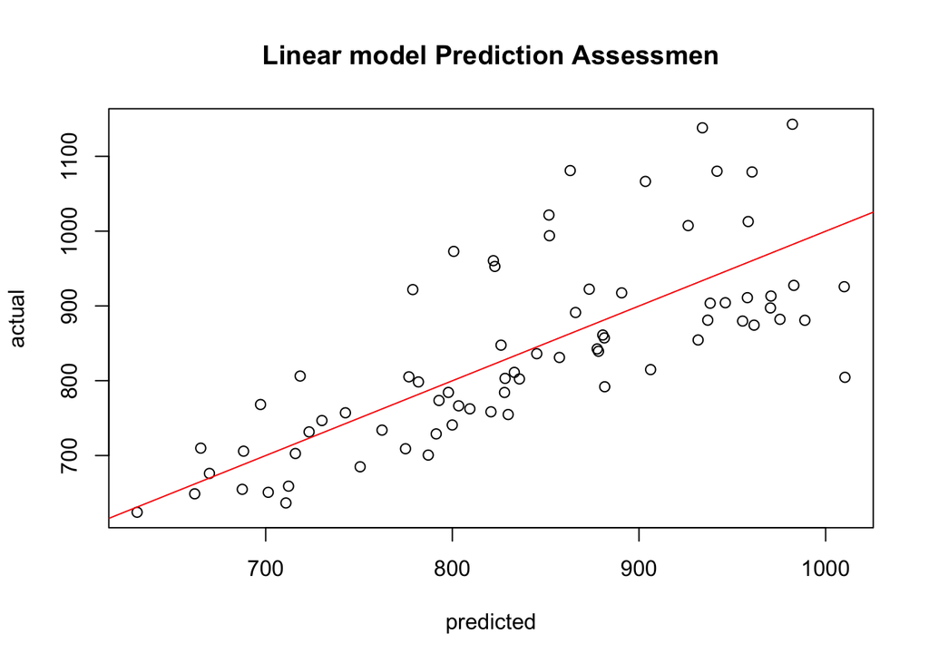

```r
#predict
trip_duration_pred_linear <- predict(trip_duration_linear, test_per_day)

#compare
plot(trip_duration_pred_linear, test_per_day$avg_trip_duration, main = "Linear model Prediction Assessmen",
     xlab = "predicted" , ylab = "actual")
abline(a = 0, b = 1, col = "red")
```

```r
#compute prediction accuracy with threshold of 5%
trip_duration_accuracy_linear = ifelse(abs(trip_duration_pred_linear - test_per_day$avg_trip_duration)/test_per_day$avg_trip_duration > 0.10, 0, 1)

trip_duration_accuracy_linear
```

```
##  1  2  3  4  5  6  7  8  9 10 11 12 13 14 15 16 17 18 19 20 21 22 23 24 25 26
##  1  1  1  0  1  1  1  1  1  1  1  0  0  1  1  0  1  1  0  0  1  0  1  1  1  1
## 27 28 29 30 31 32 33 34 35 36 37 38 39 40 41 42 43 44 45 46 47 48 49 50 51 52
##  1  1  1  0  1  0  1  1  1  1  1  1  1  0  1  1  1  1  0  1  1  0  1  1  0  0
## 53 54 55 56 57 58 59 60 61 62 63 64 65 66 67 68 69 70 71 72 73
##  0  1  1  0  1  0  1  0  1  0  1  0  1  1  1  1  1  1  1  1  1
```

### 9.1.2 KNN

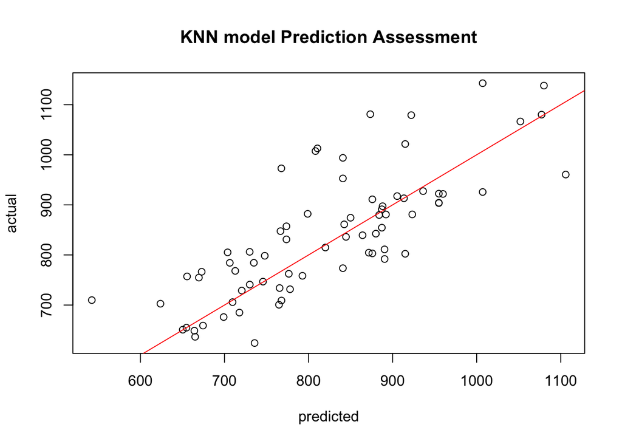

```r
#load library
library(class)

#model
train_labels = train_per_day$avg_trip_duration
test_labels = test_per_day$avg_trip_duration

#predict
trip_duration_pred_knn = knn(train = train_per_day, test = test_per_day, cl = train_labels, k = 17) #sqrt(sample size) is a rule of thumb

#compare
plot((as.numeric(levels(trip_duration_pred_knn))[trip_duration_pred_knn]), test_per_day$avg_trip_duration, main = "KNN model Prediction Assessment", xlab="predicted", ylab="actual")
abline(a = 0, b = 1, col = "red")
```

```r
#compute prediction accuracy with threshold of 5%
trip_duration_accuracy_knn = ifelse(abs((as.numeric(levels(trip_duration_pred_knn))[trip_duration_pred_knn]) - test_per_day$avg_trip_duration)/test_per_day$avg_trip_duration > 0.10, 0, 1)
```

### 9.1.3 ANN

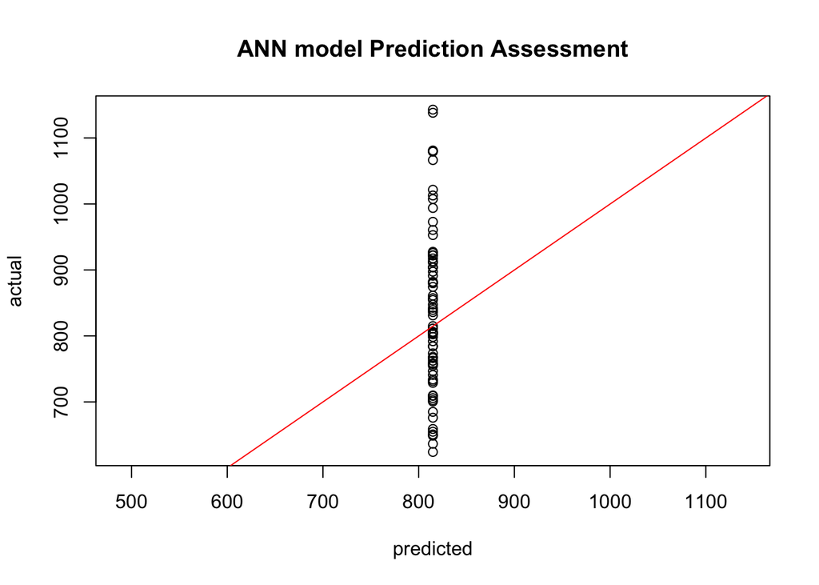

```r
#load library
library(neuralnet)

#model
trip_duration_model_ann = neuralnet(formula = avg_trip_duration ~ start_month + start_day + avg_wind_speed + TMIN + TMAX + PRCP + SNOW, data = train_per_day, hidden = 3)

#predict
trip_duration_pred_ann = compute(trip_duration_model_ann, test_per_day)
trip_duration_pred_ann_result = trip_duration_pred_ann$net.result

#compare
plot(trip_duration_pred_ann_result, test_per_day$avg_trip_duration, main = "ANN model Prediction Assessment", xlab="predicted", ylab="actual")
abline(a = 0, b = 1, col = "red")
```

```r
#compute prediction accuracy with threshold of 5%
trip_duration_accuracy_ann = ifelse(abs(trip_duration_pred_ann_result - test_per_day$avg_trip_duration)/test_per_day$avg_trip_duration > 0.10, 0, 1)
```

### 9.1.4 SVM

```r
#load library
library(kernlab)

#model
trip_duration_model_svm = ksvm(avg_trip_duration ~ start_month + start_day + avg_wind_speed + TMIN + TMAX + PRCP + SNOW, data = train_per_day, kernel = "vanilladot")
```

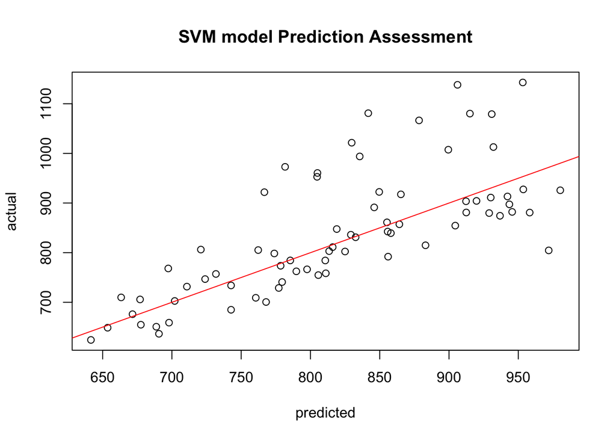

```r
#predict
trip_duration_pred_svm = predict(trip_duration_model_svm, test_per_day)

#compare
plot(trip_duration_pred_svm, test_per_day$avg_trip_duration, main = "SVM model Prediction Assessment", xlab="predicted", ylab="actual")
abline(a = 0, b = 1, col = "red")
```

```r
#compute prediction accuracy with threshold of 5%
trip_duration_accuracy_svm = ifelse(abs(trip_duration_pred_svm - test_per_day$avg_trip_duration)/test_per_day$avg_trip_duration > 0.10, 0, 1)
```

### 9.1.5 Decision Trees

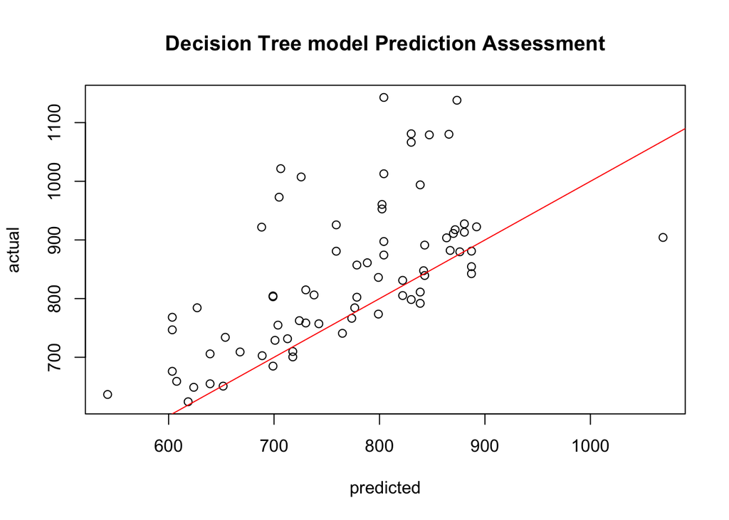

```r
#load library
library(C50)

#model
trip_duration_model_dt = C5.0(as.factor(avg_trip_duration) ~ start_month + start_day + avg_wind_speed + TMIN + TMAX + PRCP + SNOW, data = train_per_day)

#predict
trip_duration_pred_dt = predict(trip_duration_model_dt, test_per_day)

#compare
plot((as.numeric(levels(trip_duration_pred_dt))[trip_duration_pred_dt]), test_per_day$avg_trip_duration, main = "Decision Tree model Prediction Assessment", xlab="predicted", ylab="actual")
abline(a = 0, b = 1, col = "red")
```

```r
#compute prediction accuracy with threshold of 5%
trip_duration_accuracy_dt = ifelse(abs((as.numeric(levels(trip_duration_pred_dt))[trip_duration_pred_dt]) - test_per_day$avg_trip_duration)/test_per_day$avg_trip_duration > 0.10, 0, 1)
```

### 9.1.6 Random Forest

```r
#load library
library(randomForest)
```

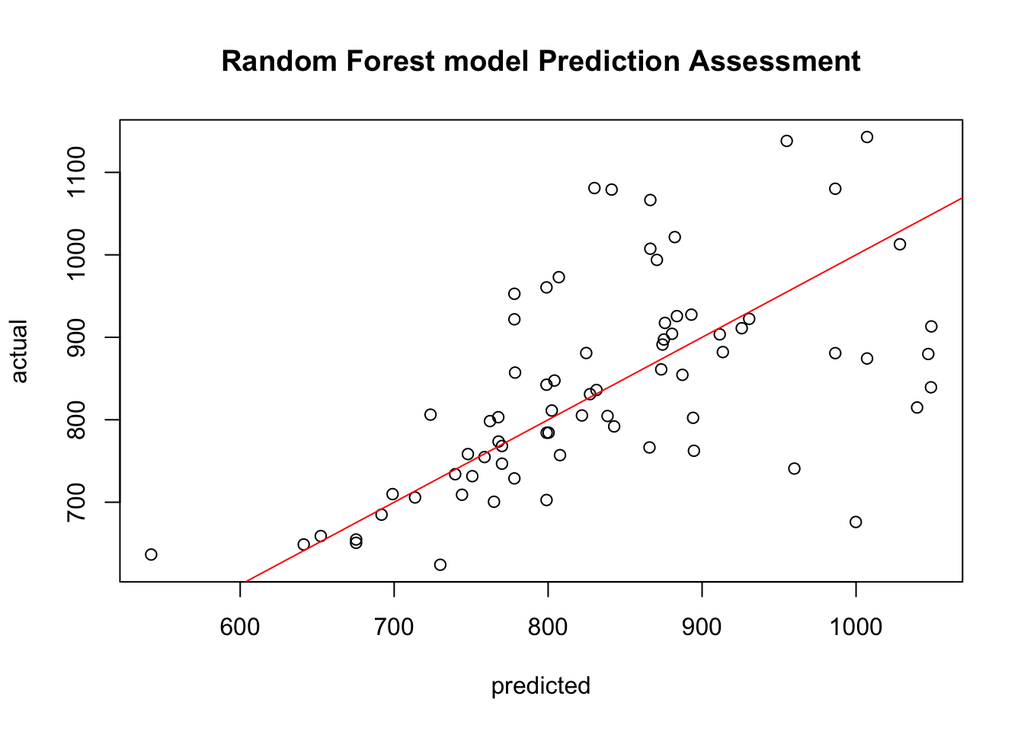

```r
#model
set.seed(12345)
trip_duration_model_rf = randomForest(as.factor(avg_trip_duration) ~ start_month + start_day + avg_wind_speed + TMIN + TMAX + PRCP + SNOW, data = train_per_day)

#predict
trip_duration_pred_rf = predict(trip_duration_model_rf, test_per_day)

#compare
plot((as.numeric(levels(trip_duration_pred_rf))[trip_duration_pred_rf]), test_per_day$avg_trip_duration, main = "Random Forest model Prediction Assessment", xlab="predicted", ylab="actual")
abline(a = 0, b = 1, col = "red")
```

```r
#compute prediction accuracy with threshold of 5%
trip_duration_accuracy_rf = ifelse(abs((as.numeric(levels(trip_duration_pred_rf))[trip_duration_pred_rf]) - test_per_day$avg_trip_duration)/test_per_day$avg_trip_duration > 0.10, 0, 1)
```

### 9.1.7 Assess Models

```r
trip_duration_model_comparison = matrix(0, nrow=6, ncol=3)
colnames(trip_duration_model_comparison) = c("bad_prediction","good_prediction", "accuracy")
rownames(trip_duration_model_comparison) = c("linear","knn","ann","svm","decision_tree","random_forst")

trip_duration_model_comparison[1,] = c((length(trip_duration_accuracy_linear)-sum(trip_duration_accuracy_linear)), sum(trip_duration_accuracy_linear), round(sum(trip_duration_accuracy_linear)/length(trip_duration_accuracy_linear),3))
trip_duration_model_comparison[2,] = c((length(trip_duration_accuracy_knn)-sum(trip_duration_accuracy_knn)), sum(trip_duration_accuracy_knn), round(sum(trip_duration_accuracy_knn)/length(trip_duration_accuracy_knn),3))
trip_duration_model_comparison[3,] = c((length(trip_duration_accuracy_ann)-sum(trip_duration_accuracy_ann)), sum(trip_duration_accuracy_ann), round(sum(trip_duration_accuracy_ann)/length(trip_duration_accuracy_ann),3))
trip_duration_model_comparison[4,] = c((length(trip_duration_accuracy_svm)-sum(trip_duration_accuracy_svm)), sum(trip_duration_accuracy_svm), round(sum(trip_duration_accuracy_svm)/length(trip_duration_accuracy_svm),3))
trip_duration_model_comparison[5,] = c((length(trip_duration_accuracy_dt)-sum(trip_duration_accuracy_dt)), sum(trip_duration_accuracy_dt), round(sum(trip_duration_accuracy_dt)/length(trip_duration_accuracy_dt),3))
trip_duration_model_comparison[6,] = c((length(trip_duration_accuracy_rf)-sum(trip_duration_accuracy_rf)), sum(trip_duration_accuracy_rf), round(sum(trip_duration_accuracy_rf)/length(trip_duration_accuracy_rf),3))
```

### 9.1.8 Findings

Based on the different models assessed, SVM gave the best prediction of average trip duration with the accuracy of ~79.5%. This is considering that the results are accurate if lying within 10% range of the actual trip duration value.

From the linear model, it can be concluded that there is a relationship between average trip duration and different weather parameters. For example, it was found that TMAX had a positive relationship and PRCP had a negative relationship with average trip duration. From this, it can be concluded that warmer days have longer rides and rainy days have shorter rides in general.

There was no significant impact of variables TMIN, SNOW, start_month, and start_day. This indicates that the trip duration is not impacted by lower temperatures, snow amount, and trip month or day.

```r
trip_duration_model_comparison
```

```
##               bad_prediction good_prediction accuracy
## linear                    20              53    0.726
## knn                       19              54    0.740
## ann                       36              37    0.507
## svm                       15              58    0.795
## decision_tree             27              46    0.630
## random_forst              27              46    0.630
```

## 9.2 Avg speed per day

### 9.2.1 Linear Model

```r
#model
speed_model_linear = lm(avg_speed ~ start_month + start_day + avg_wind_speed + TMIN + TMAX + PRCP + SNOW, data = train_per_day)

summary(speed_model_linear)
```

```
##
## Call:
## lm(formula = avg_speed ~ start_month + start_day + avg_wind_speed +
##     TMIN + TMAX + PRCP + SNOW, data = train_per_day)
##
## Residuals:
##      Min       1Q   Median       3Q      Max
## -0.27389 -0.07950  0.02405  0.07763  0.22919
##
## Coefficients:
##                  Estimate Std. Error t value Pr(>|t|)
## (Intercept)     2.6593008  0.0261865 101.552  < 2e-16 ***
## start_month    -0.0109588  0.0024061  -4.555 7.80e-06 ***
## start_day      -0.0010170  0.0007656  -1.328 0.185169
## avg_wind_speed  0.0154658  0.0067803   2.281 0.023290 *
## TMIN            0.0032415  0.0026377   1.229 0.220122
## TMAX           -0.0121248  0.0023692  -5.118 5.71e-07 ***
## PRCP            0.0029408  0.0008760   3.357 0.000895 ***
## SNOW           -0.0134834  0.0077187  -1.747 0.081745 .
## ---
## Signif. codes:  0 '***' 0.001 '**' 0.01 '*' 0.05 '.' 0.1 ' ' 1
##
## Residual standard error: 0.1112 on 284 degrees of freedom
## Multiple R-squared:  0.4905, Adjusted R-squared:  0.4779
## F-statistic: 39.06 on 7 and 284 DF,  p-value: < 2.2e-16
```

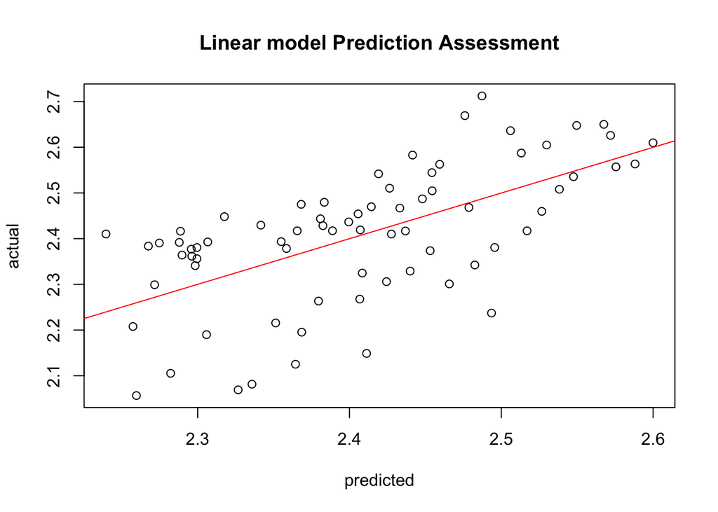

```r
#predict
speed_pred_linear = predict(speed_model_linear, newdata = test_per_day)

#compare
plot(speed_pred_linear, test_per_day$avg_speed, main = "Linear model Prediction Assessment", xlab="predicted", ylab="actual")
abline(a = 0, b = 1, col = "red")
```

```r
#compute prediction accuracy with threshold of 5%
speed_accuracy_linear = ifelse(abs(speed_pred_linear - test_per_day$avg_speed)/test_per_day$avg_speed > 0.05, 0, 1)
```

### 9.2.2 KNN

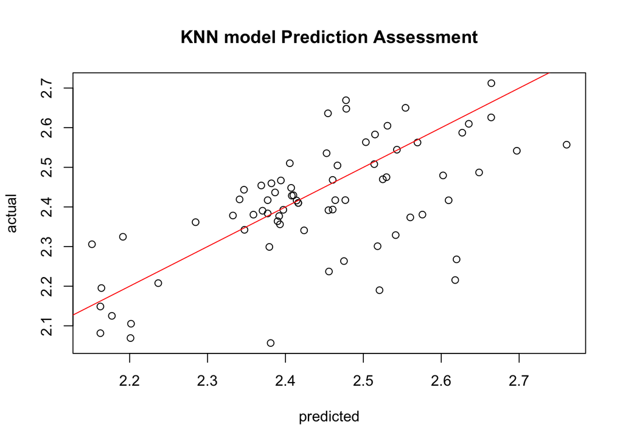

```r
#load library
library(class)

#model
train_labels = train_per_day$avg_speed
test_labels = test_per_day$avg_speed

#predict
speed_pred_knn = knn(train = train_per_day, test = test_per_day, cl = train_labels, k = 17) #sqrt(sample size) is a rule of thumb

#compare
plot((as.numeric(levels(speed_pred_knn))[speed_pred_knn]), test_per_day$avg_speed, main = "KNN model Prediction Assessment", xlab="predicted", ylab="actual")
abline(a = 0, b = 1, col = "red")
```

```r
#compute prediction accuracy with threshold of 5%
speed_accuracy_knn = ifelse(abs((as.numeric(levels(speed_pred_knn))[speed_pred_knn]) - test_per_day$avg_speed)/test_per_day$avg_speed > 0.05, 0, 1)
```

### 9.2.3 ANN

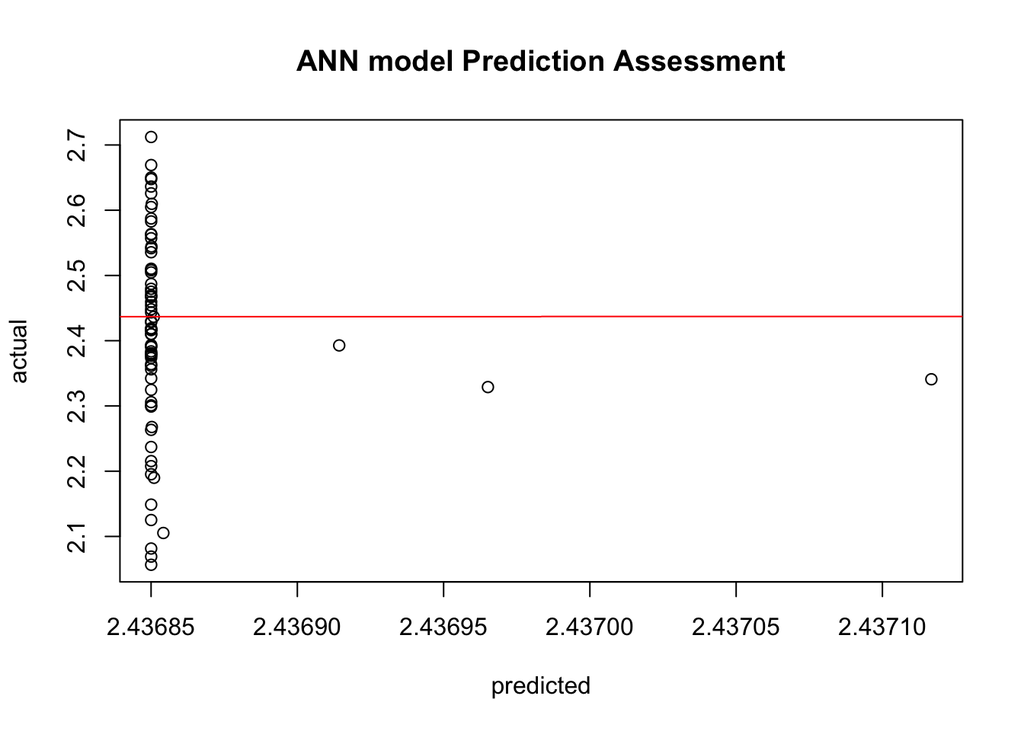

```r
#load library
library(neuralnet)

#model
speed_model_ann = neuralnet(formula = avg_speed ~ start_month + start_day + avg_wind_speed + TMIN + TMAX + PRCP + SNOW, data = train_per_day, hidden = 3)

#predict
speed_pred_ann = compute(speed_model_ann, test_per_day)
speed_pred_ann_result = speed_pred_ann$net.result

#compare
plot(speed_pred_ann_result, test_per_day$avg_speed, main = "ANN model Prediction Assessment", xlab="predicted", ylab="actual")
abline(a = 0, b = 1, col = "red")
```

```r
#compute prediction accuracy with threshold of 5%
speed_accuracy_ann = ifelse(abs(speed_pred_ann_result - test_per_day$avg_speed)/test_per_day$avg_speed > 0.05, 0, 1)
```

### 9.2.4 SVM

```r
#load library
library(kernlab)

#model
speed_model_svm = ksvm(avg_speed ~ start_month + start_day + avg_wind_speed + TMIN + TMAX + PRCP + SNOW, data = train_per_day, kernel = "vanilladot")
```

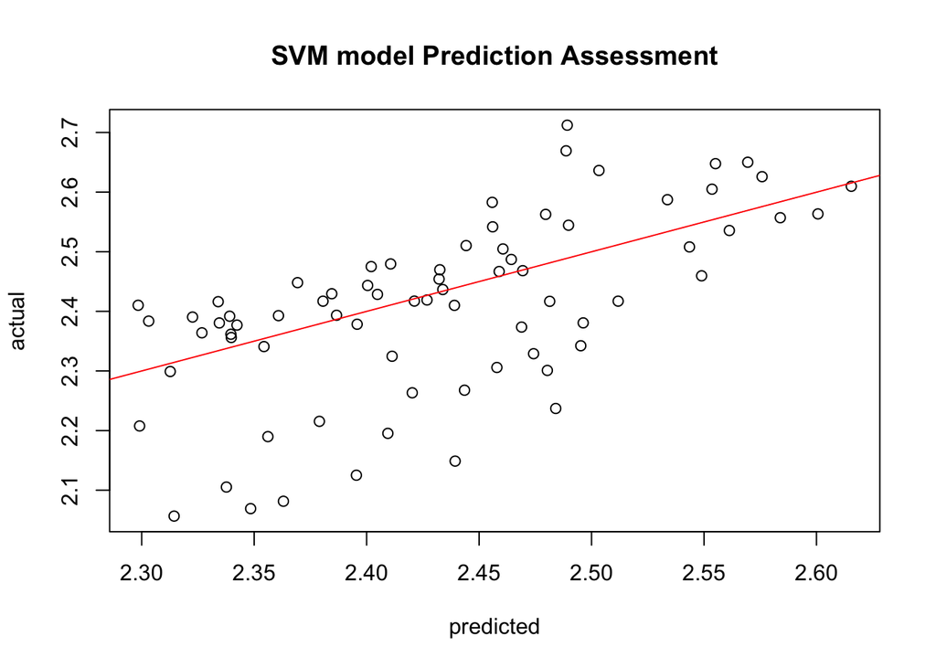

```r
#predict
speed_pred_svm = predict(speed_model_svm, test_per_day)

#compare
plot(speed_pred_svm, test_per_day$avg_speed, main = "SVM model Prediction Assessment", xlab="predicted", ylab="actual")
abline(a = 0, b = 1, col = "red")
```

```r
#compute prediction accuracy with threshold of 5%
speed_accuracy_svm = ifelse(abs(speed_pred_svm - test_per_day$avg_speed)/test_per_day$avg_speed > 0.05, 0, 1)
```

### 9.2.5 Decision Trees

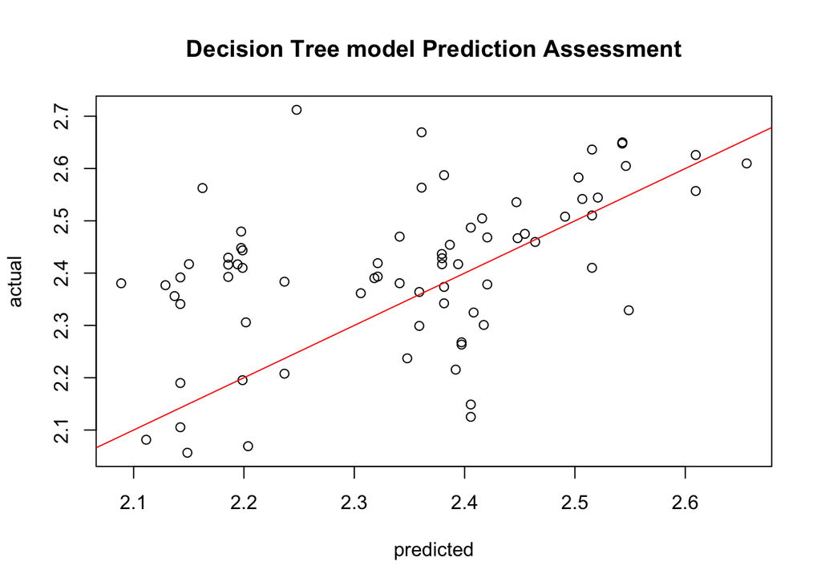

```r
#load library
library(C50)

#model
speed_model_dt = C5.0(as.factor(avg_speed) ~ start_month + start_day + avg_wind_speed + TMIN + TMAX + PRCP + SNOW, data = train_per_day)

#predict
speed_pred_dt = predict(speed_model_dt, test_per_day)

#compare
plot((as.numeric(levels(speed_pred_dt))[speed_pred_dt]), test_per_day$avg_speed, main = "Decision Tree model Prediction Assessment", xlab="predicted", ylab="actual")
abline(a = 0, b = 1, col = "red")
```

```r
#compute prediction accuracy with threshold of 5%
speed_accuracy_dt = ifelse(abs((as.numeric(levels(speed_pred_dt))[speed_pred_dt]) - test_per_day$avg_speed)/test_per_day$avg_speed > 0.05, 0, 1)
```

### 9.2.6 Random Forest

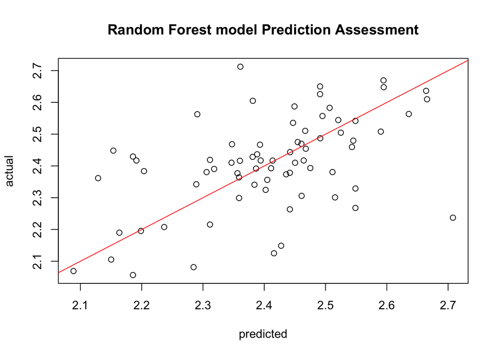

```r
#load library
library(randomForest)

#model
set.seed(12345)
speed_model_rf = randomForest(as.factor(avg_speed) ~ start_month + start_day + avg_wind_speed + TMIN + TMAX + PRCP + SNOW, data = train_per_day)

#predict
speed_pred_rf = predict(speed_model_rf, test_per_day)

#compare
plot((as.numeric(levels(speed_pred_rf))[speed_pred_rf]), test_per_day$avg_speed, main = "Random Forest model Prediction Assessment", xlab="predicted", ylab="actual")
abline(a = 0, b = 1, col = "red")
```

```r
#compute prediction accuracy with threshold of 5%
speed_accuracy_rf = ifelse(abs((as.numeric(levels(speed_pred_rf))[speed_pred_rf]) - test_per_day$avg_speed)/test_per_day$avg_speed > 0.05, 0, 1)
```

### 9.2.7 Assess Models

```r
speed_model_comparison = matrix(0, nrow=6, ncol=3)
colnames(speed_model_comparison) = c("bad_prediction","good_prediction", "accuracy")
rownames(speed_model_comparison) = c("linear","knn","ann","svm","decision_tree","random_forst")

speed_model_comparison[1,] = c((length(speed_accuracy_linear)-sum(speed_accuracy_linear)), sum(speed_accuracy_linear), round(sum(speed_accuracy_linear)/length(speed_accuracy_linear),3))
speed_model_comparison[2,] = c((length(speed_accuracy_knn)-sum(speed_accuracy_knn)), sum(speed_accuracy_knn), round(sum(speed_accuracy_knn)/length(speed_accuracy_knn),3))
speed_model_comparison[3,] = c((length(speed_accuracy_ann)-sum(speed_accuracy_ann)), sum(speed_accuracy_ann), round(sum(speed_accuracy_ann)/length(speed_accuracy_ann),3))
speed_model_comparison[4,] = c((length(speed_accuracy_svm)-sum(speed_accuracy_svm)), sum(speed_accuracy_svm), round(sum(speed_accuracy_svm)/length(speed_accuracy_svm),3))
speed_model_comparison[5,] = c((length(speed_accuracy_dt)-sum(speed_accuracy_dt)), sum(speed_accuracy_dt), round(sum(speed_accuracy_dt)/length(speed_accuracy_dt),3))
speed_model_comparison[6,] = c((length(speed_accuracy_rf)-sum(speed_accuracy_rf)), sum(speed_accuracy_rf), round(sum(speed_accuracy_rf)/length(speed_accuracy_rf),3))
```

### 9.2.8 Findings

```r
speed_model_comparison
```

```
##               bad_prediction good_prediction accuracy
## linear                    21              52    0.712
## knn                       20              53    0.726
## ann                       26              47    0.644
## svm                       19              54    0.740
## decision_tree             29              44    0.603
## random_forst              22              51    0.699
```